# Problem:

> **Clustering Data Using the K-means Algorithm (Unsupervised Learning)**

Objectives

- Build a Kmeans model using the sklearn library.
- Apply two models to solve a real-world problem (image compression).
- Understand how to tune parameters and evaluate model quality.

Data

- Kmeans Simulation Problem: Use sklearn's automatic data generation function (generating random points according to the Gaussian distribution). Each data point is a point on the Oxy plane.
- Image Compression Problem: Image bird_small.png (Picture of a bird)

Modeling the Problem: Clustering problem.

- Input: $N$ vectors of $D$ dimensions, corresponding to $N$ data points with $D$ attributes in space. Initial number of clusters.
- Output: Cluster centers and cluster indices of each given data point.

## 1. Exercise 1: Kmeans Simulation with Generated Data (Oxy Plane)

### 1.1. Import Libraries

- Import necessary libraries such as numpy, matplotlib, and sklearn.

```python
import numpy as np
import matplotlib.pyplot as plt

from sklearn.cluster import KMeans
from sklearn.datasets import make_blobs
import warnings
warnings.filterwarnings('ignore')
```

```python
import os
import gdown

# Create a directory if it doesn't exist
os.makedirs("images", exist_ok=True)

# URL of the file to download
url = 'https://drive.google.com/drive/folders/1v0GCI5FRU6m0r0uSXceskAxAlbT6ogTW'

# Download the file into the data directory
gdown.download_folder(url, output='images', quiet=False)
```

```
Retrieving folder contents
```

```
Processing file 10Ak296H95TrEejEq4xf8-SEU8cgAzPnc bird_small.png
Processing file 1knLJJRj4ld4o5LgYUrajNgl4qkPk48cf img128.png
```

```
Retrieving folder contents completed
Building directory structure
Building directory structure completed
Downloading...
From: https://drive.google.com/uc?id=10Ak296H95TrEejEq4xf8-SEU8cgAzPnc
To: /Users/laien/Desktop/HW/ML/images/bird_small.png
Downloading...
From: https://drive.google.com/uc?id=1knLJJRj4ld4o5LgYUrajNgl4qkPk48cf
To: /Users/laien/Desktop/HW/ML/images/img128.png
Download completed
```

```
['images/bird_small.png', 'images/img128.png']
```

### 1.2. Data Preparation

- Generate random data with `n_samples = 100`, equivalent to 100 points
  - `random_state`: a fixed random variable to ensure reproducibility of randomly generated points
- Each data point has 2 dimensions

```python
n_samples = 100
random_state = 42
center_points = [[1, 1], [-1, -1], [1, -1]] # generate random points around fixed centers
# center_points = 3                        # centers are chosen randomly

X, y = make_blobs(n_samples=n_samples, random_state=random_state, centers=center_points, cluster_std=0.6)
print("Data dimensions: ", X.shape, y.shape)
print("First 5 data points: \n", X[:5])
```

```
Data dimensions:  (100, 2) (100,)
First 5 data points:
 [[ 1.28394257 -1.04369735]
 [ 0.49646949  0.81447257]
 [-2.15126273 -1.01590833]
 [ 0.71249546  0.88860461]
 [ 0.415191   -0.52774924]]
```

```python
set(y)
```

```
{np.int64(0), np.int64(1), np.int64(2)}
```

**Plotting Pixels Using Matplotlib**

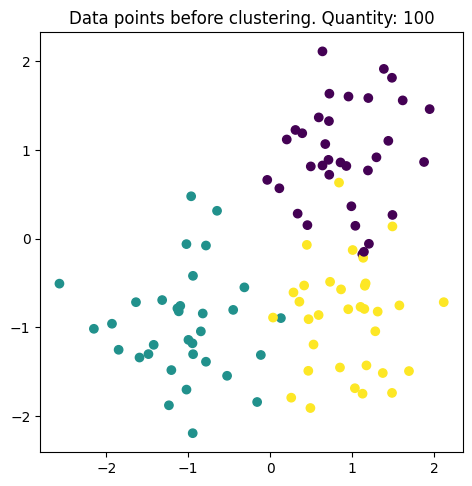

```python
plt.figure(figsize=(12, 12))
plt.subplot(221)
plt.scatter(X[:, 0], X[:, 1], c=y, cmap='viridis') # c is the parameter for choosing color, can pass string or id number 1, 2, 3, ...
plt.title("Data points before clustering. Quantity: {}".format(n_samples))
plt.show()
```

### 1.3. Implementing and Training the K-means Algorithm

- Use the sklearn library to implement the K-means algorithm, see details in the [documentation](https://scikit-learn.org/stable/modules/generated/sklearn.cluster.KMeans.html)

```python
k_cluster = 3
k_mean_model = KMeans(n_clusters=k_cluster, random_state=random_state)
k_mean_model.fit(X)

centers = np.array(k_mean_model.cluster_centers_) # cluster_centers_: is the attribute that stores
                                                  # the cluster centers after training
print("Cluster centers after training ({} centers): \n".format(k_cluster),
      centers)
```

```
Cluster centers after training (3 centers):
 [[ 0.92215161 -0.89765135]
 [-1.09266234 -0.9783299 ]
 [ 0.90169798  0.9928998 ]]
```

### 1.4. Model Evaluation

- Check which clusters the data points belong to
- Plot a chart showing the data points, with different colors for different clusters

```
Prediction results for the first 5 data samples in the dataset:

[0 2 1 2 0]
```

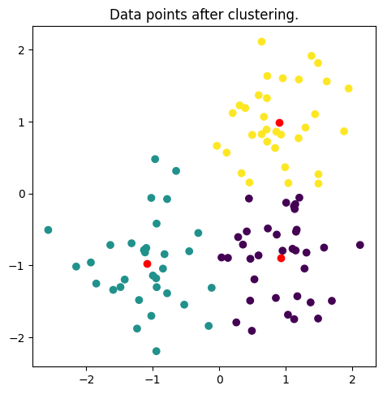

```python
y_pred = k_mean_model.predict(X)
print("Prediction results for the first 5 data samples in the dataset: \n")
print(y_pred[:5])

plt.figure(figsize=(12, 12))
plt.subplot(222)
plt.scatter(X[:, 0], X[:, 1], c=y_pred)
plt.scatter(centers[:, 0], centers[:, 1], c='red')
plt.title("Data points after clustering.")
plt.show()
```

### 1.5. Homework 1

- Write code to generate data similar to the above
- Build models with list k clusters

Hint: change the number of clusters parameter when implementing the K-means algorithm

The result should display the correct number of cluster centers and the cluster distribution.

```
Data dimensions:  (1000, 2) (1000,)
First 5 data points:
 [[ 0.76242453 10.12556447]
 [26.6930883   1.40278528]
 [25.80381843  2.08536351]
 [26.04639346  1.75782377]
 [26.27422645  2.04258763]]
[1 2 3 4 5 6 7 8 9]
```

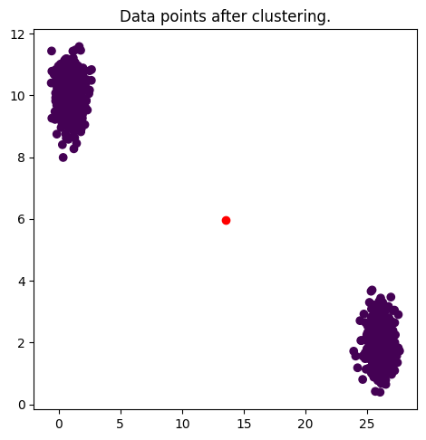

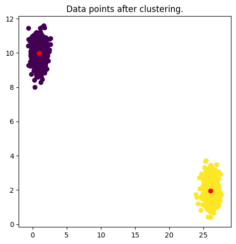

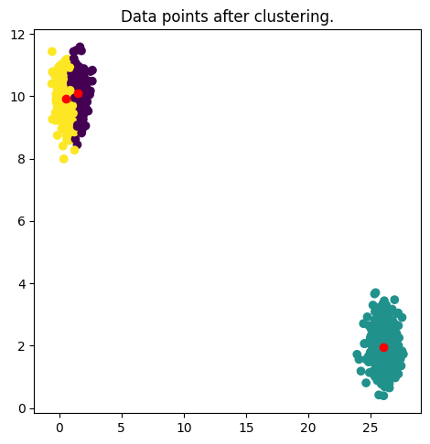

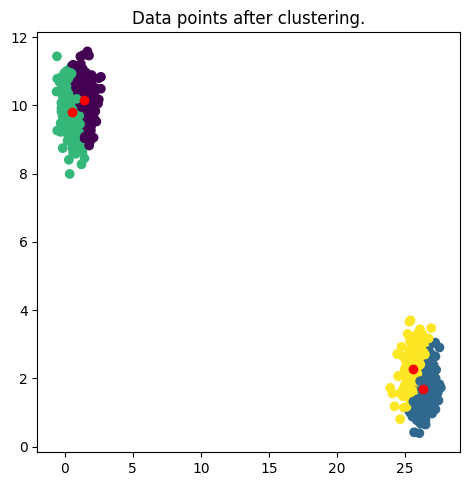

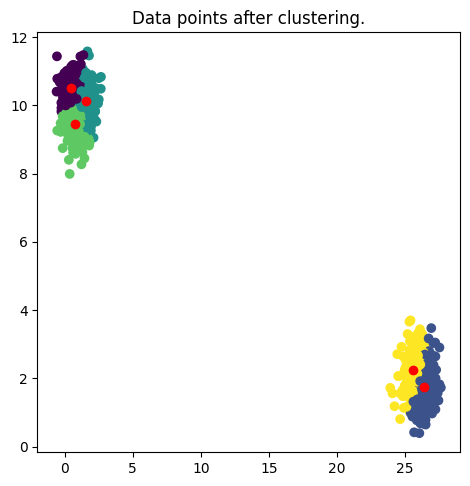

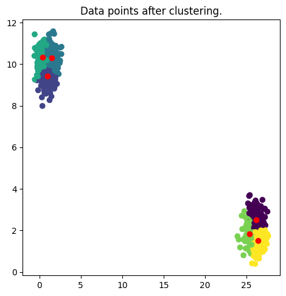

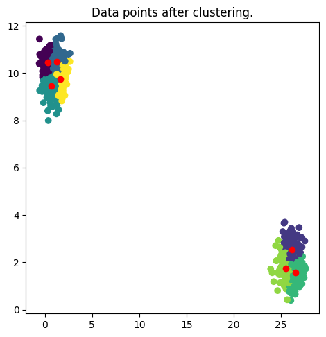

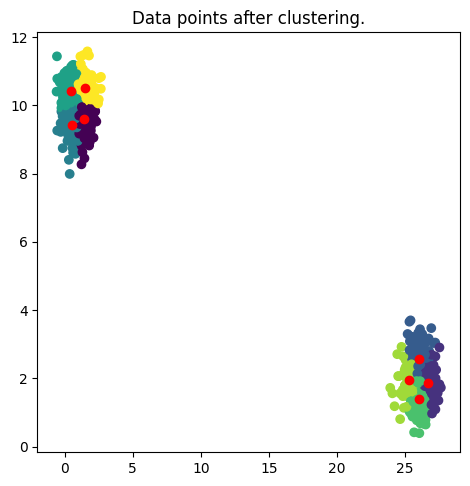

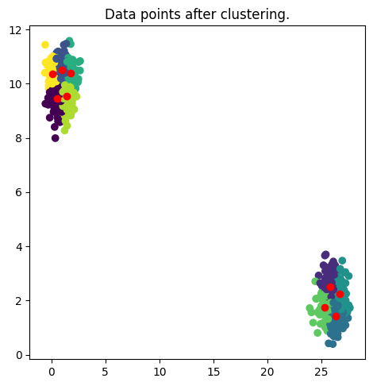

```python
# Generate data corresponding to the hypothesis of 2 clusters
import numpy as np
n_samples = 1000
random_state = 170
center_points = [[1, 10], [26, 2]] # randomly generate points around fixed center positions
# center_points = 3                           # cluster centers chosen randomly

X, y = make_blobs(n_samples=n_samples, random_state=random_state, centers=center_points, cluster_std=0.6)
print("Data dimensions: ", X.shape, y.shape)
print("First 5 data points: \n", X[:5])
k_cluster = np.arange(1,10)
print(k_cluster)
for k in k_cluster:

    ### Your code here ...
    # Initialize and fit the KMeans model
    model_hw1 = KMeans(n_clusters=k, random_state=42, n_init=10)
    model_hw1.fit(X)
    # Get the cluster centers
    centers = model_hw1.cluster_centers_

    # Predict the cluster for each data point
    y_pred = model_hw1.labels_

    ### Your code here ...

    plt.figure(figsize=(12, 12))
    plt.subplot(222)
    plt.scatter(X[:, 0], X[:, 1], c=y_pred)
    plt.scatter(centers[:, 0], centers[:, 1], c='red')
    plt.title("Data points after clustering.")
    plt.show()
```

## 2. Exercise 2: Applying K-means for Image Compression

- Problem Statement:
  - Want to build a data compression system for images.
  - Can customize sharpness, reduce memory size, but not significantly distort visually.
- Solution:
  - Use the K-means algorithm to automatically cluster image pixels, limit the number of colors to reduce image size.
  - Each pixel will be assigned to a cluster, taking the color value of the cluster center.

```python
import imageio
from sklearn.cluster import KMeans
import numpy as np
import matplotlib.pyplot as plt
import matplotlib.image as image
from IPython.core.display import Image, display
```

### 2.1. Read Image Data

- Each pixel is considered as one observation.
- Cluster the dataset (set of pixels) into k labels.

```python
path_img = 'images/bird_small.png'

display(Image(path_img, width=250, unconfined=True))
```

[output not shown]

```python
img = imageio.imread(path_img)
img
```

```
array([[[219, 180, 103],
        [230, 185, 116],
        [226, 186, 110],
        ...,
        [ 14,  15,  13],
        [ 13,  15,  12],
        [ 12,  14,  12]],

       [[230, 193, 119],
        [224, 192, 120],
        [226, 192, 124],
        ...,
        [ 16,  16,  13],
        [ 14,  15,  10],
        [ 11,  14,   9]],

       [[228, 191, 123],
        [228, 191, 121],
        [220, 185, 118],
        ...,
        [ 14,  16,  13],
        [ 13,  13,  11],
        [ 11,  15,  10]],

       ...,

       [[ 15,  18,  16],
        [ 18,  21,  18],
        [ 18,  19,  16],
        ...,
        [ 81,  45,  45],
        [ 70,  43,  35],
        [ 72,  51,  43]],

       [[ 16,  17,  17],
        [ 17,  18,  19],
        [ 20,  19,  20],
        ...,
        [ 80,  38,  40],
        [ 68,  39,  40],
        [ 59,  43,  42]],

       [[ 15,  19,  19],
        [ 20,  20,  18],
        [ 18,  19,  17],
        ...,
        [ 65,  43,  39],
        [ 58,  37,  38],
        [ 52,  39,  34]]], dtype=uint8)
```

```python
path_img = 'images/bird_small.png'

display(Image(path_img, width=250, unconfined=True))

img = imageio.imread(path_img)
print("Image data before reshape:", img.shape)

img_shape = img.shape # 128x128x3
data_img = (img / 255.0).reshape(-1, img.shape[2]) # reshape the 128x128x3 matrix into a 2D array, keeping the shape[2] dimension

print("Dimension of image data: ", data_img.shape)
print("Total number of pixels: ", data_img.shape[0])
print("Each pixel has dimensions = ", data_img.shape[1])
```

```
Image data before reshape: (128, 128, 3)
Dimension of image data:  (16384, 3)
Total number of pixels:  16384
Each pixel has dimensions =  3
```

### 2.2. Build K-means Model for Image Compression

- The number of clusters corresponds to the number of colors we retain.
- The smaller the number of clusters, the smaller the resulting image size.

```python
n_color = 10
k_mean_model = KMeans(n_clusters=n_color)
```

**Train the Model**

```python
k_mean_model.fit(data_img)
```

```
KMeans(n_clusters=10)
```

```python
# Display some information learned by the model
print("Dimension of cluster centers: ", k_mean_model.cluster_centers_.shape)
print(k_mean_model.cluster_centers_)
print(k_mean_model.labels_[0:20])
```

```
Dimension of cluster centers:  (10, 3)
[[0.09240739 0.09972751 0.08974001]
 [0.78785392 0.56848651 0.2765991 ]
 [0.91754327 0.80548683 0.65071952]
 [0.58479826 0.51313978 0.47626958]
 [0.84291385 0.69685175 0.45233799]
 [0.97057482 0.93825393 0.80453292]
 [0.38381012 0.33008821 0.31603194]
 [0.60772119 0.66372709 0.76000128]
 [0.56940494 0.41631373 0.20678261]
 [0.21365626 0.20074629 0.19036388]]
[4 4 4 4 4 4 4 4 4 4 4 4 4 4 4 4 4 4 4 4]
```

### 2.3. Display the compressed image

```python
# k_mean_model.labels_: contains labels of all pixels
# k_mean_model.cluster_centers_: contains cluster centers

# Create the compressed image array
compressed_img = k_mean_model.cluster_centers_[k_mean_model.labels_]

print(compressed_img.shape)

# Reshape the image array back to its original dimensions
compressed_img = np.reshape(compressed_img, img_shape)
print(compressed_img.shape)

# Save the compressed image
image.imsave('images/compressed_image.png', compressed_img)
```

```
(16384, 3)
(128, 128, 3)
```

```python
import os

# Display the size of the compressed and original images
print('Size of original image: ' + str(os.path.getsize('images/bird_small.png')) + ' KB')
print('Size of compressed image: ' + str(os.path.getsize('images/compressed_image.png')) + ' KB')
```

```
Size of original image: 33031 KB
Size of compressed image: 6814 KB
```

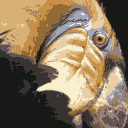

```python
from IPython.core.display import Image, display

#Save image
display(Image('images/compressed_image.png', width=250, unconfined=True))
display(Image(path_img, width=250, unconfined=True))
```

### Homework 2

Requirement: Compress the image to have fewer than 10 colors and check.

Hint: Change the "number of clusters" parameter when building K-means.

[output not shown]

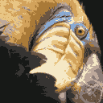

```
Number of clusters: 2
Size of compressed image: 6892 KB
Size of original image: 33031 KB
```

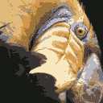

```
Number of clusters: 3
Size of compressed image: 6918 KB
Size of original image: 33031 KB
```

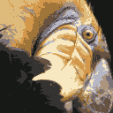

```
Number of clusters: 4
Size of compressed image: 6460 KB
Size of original image: 33031 KB
```

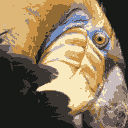

```
Number of clusters: 5
Size of compressed image: 6848 KB
Size of original image: 33031 KB
```

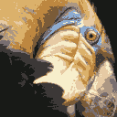

```
Number of clusters: 6
Size of compressed image: 6461 KB
Size of original image: 33031 KB
```

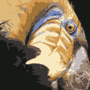

```
Number of clusters: 7
Size of compressed image: 6474 KB
Size of original image: 33031 KB
```

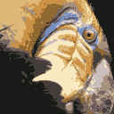

```
Number of clusters: 8
Size of compressed image: 6475 KB
Size of original image: 33031 KB
```

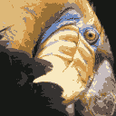

```
Number of clusters: 9
Size of compressed image: 6858 KB
Size of original image: 33031 KB
```

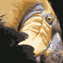

```python
# code
k_cluster = np.arange(1, 10)
for k in k_cluster:
    ### Your Code here

    # Initialize and fit the KMeans model
    model_hw2 = KMeans(n_clusters=k, random_state=42, n_init='auto')
    k_mean_model.fit(data_img)
    # Create the compressed image array
    compressed_img = k_mean_model.cluster_centers_[k_mean_model.labels_]

    # Reshape the image array back to its original dimensions
    compressed_img =np.reshape(compressed_img, img_shape)
    ### Your Code here

    # Save the compressed image
    image.imsave('images/img128.png', compressed_img)

    # Display the compressed image size and the original image
    import os
    print('Number of clusters:', k)
    print('Size of compressed image: ' + str(os.path.getsize('images/img128.png')) + ' KB')
    print('Size of original image: ' + str(os.path.getsize('images/bird_small.png')) + ' KB')

    # Display the compressed image
    from IPython.display import Image, display
    display(Image('images/img128.png', width=250, unconfined=True))
```

### Homework 3

請用MNIST將0-9各取100個點，呈現降維後使用K-Means的視覺圖

分別使用

1. pca
2. UMAP
3. t-SNE

```
程式開始執行...
原始資料維度: (60000, 784)
原始標籤數量: 60000
--------------------------------------------------
取樣後資料維度: (1000, 784)
取樣後標籤分佈: [(np.uint8(0), 100), (np.uint8(1), 100), (np.uint8(2), 100), (np.uint8(3), 100), (np.uint8(4), 100), (np.uint8(5), 100), (np.uint8(6), 100), (np.uint8(7), 100), (np.uint8(8), 100), (np.uint8(9), 100)]

[1] 正在執行 PCA...
```

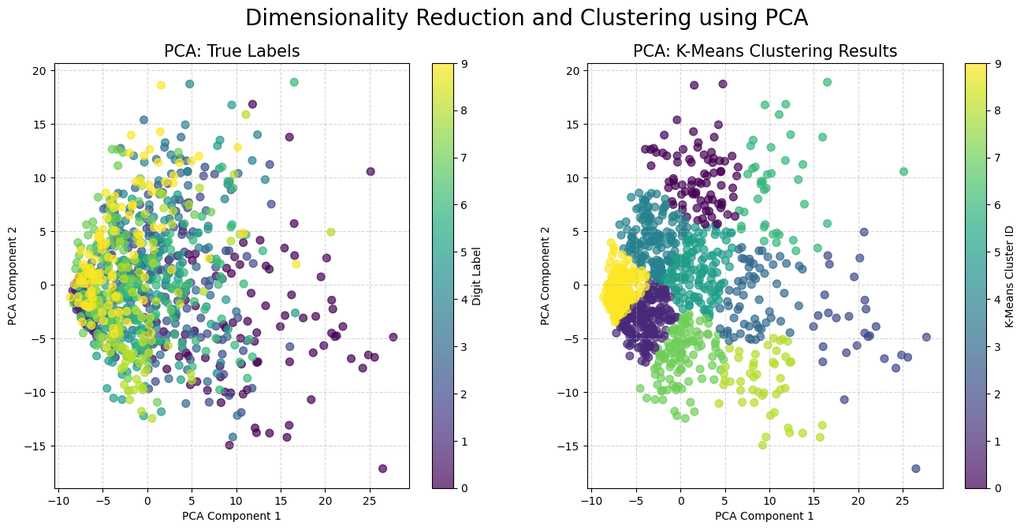

```
[2] 正在執行 UMAP...
```

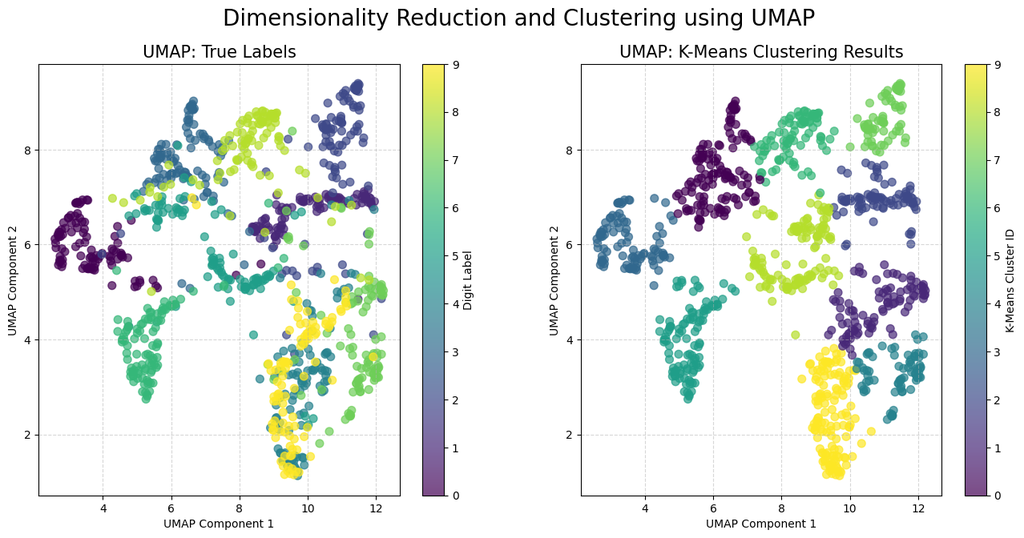

```
[3] 正在執行 t-SNE (可能需要一點時間)...
```

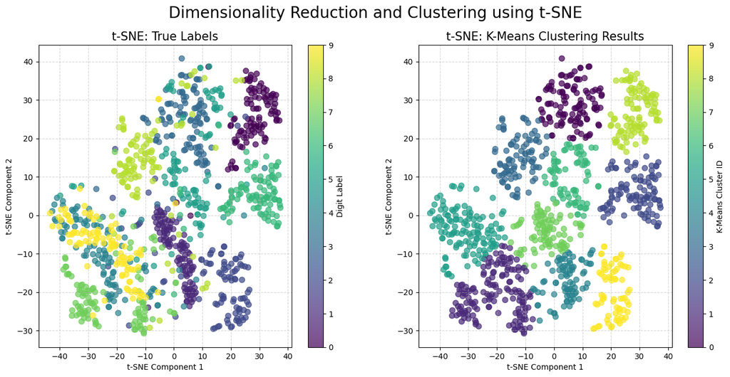

```
程式執行完畢！
```

```python
### code start here
import numpy as np
import matplotlib.pyplot as plt
from collections import Counter

# --- 機器學習與降維工具 ---
from sklearn.preprocessing import StandardScaler
from sklearn.decomposition import PCA
from sklearn.manifold import TSNE
from sklearn.cluster import KMeans
import umap.umap_ as umap# UMAP 需要另外安裝: pip install umap-learn

# --- 資料載入工具 ---
# 使用 TensorFlow 來方便地載入 MNIST 資料集
import tensorflow as tf

print("程式開始執行...")

# ===================================================================
# 步驟一：載入並準備 MNIST 資料
# ===================================================================

# 載入資料集
(x_train, y_train), (_, _) = tf.keras.datasets.mnist.load_data()

# 將 28x28 的圖片攤平成 784 維的向量
# 並將像素值從 0-255 標準化到 0-1 之間，有助於演算法收斂
X_flat = x_train.reshape(-1, 28 * 28).astype('float32') / 255.0

print(f"原始資料維度: {X_flat.shape}")
print(f"原始標籤數量: {len(y_train)}")

# ===================================================================
# 步驟二：從每個類別中抽取 100 個樣本
# ===================================================================

X_sample = []
y_sample = []
samples_per_class = 100
num_classes = 10

# 設定隨機種子以確保每次執行的結果都一樣
np.random.seed(42)

for digit in range(num_classes):
    # 找到所有屬於目前 digit 的資料索引
    indices = np.where(y_train == digit)[0]
    # 從中隨機選取 100 個索引 (不重複)
    random_indices = np.random.choice(indices, samples_per_class, replace=False)

    # 將選中的資料和標籤加入我們的樣本集中
    X_sample.append(X_flat[random_indices])
    y_sample.append(y_train[random_indices])

# 將 list 轉換成 numpy array
X_sample = np.concatenate(X_sample, axis=0)
y_sample = np.concatenate(y_sample, axis=0)

print("-" * 50)
print(f"取樣後資料維度: {X_sample.shape}")
print(f"取樣後標籤分佈: {sorted(Counter(y_sample).items())}")

# 資料標準化: 對於 PCA 尤其重要
scaler = StandardScaler()
X_scaled = scaler.fit_transform(X_sample)

# ===================================================================
# 步驟三：定義一個繪圖函數，方便重複使用
# ===================================================================

def plot_clusters(data_2d, true_labels, kmeans_labels, title_prefix):
    """
    繪製兩張圖:
    1. 左圖: 根據真實標籤上色，觀察降維後類別的分佈情況。
    2. 右圖: 根據 K-Means 分群結果上色，觀察分群效果。
    """
    fig, axes = plt.subplots(1, 2, figsize=(16, 7))

    # --- 左圖：真實標籤 (Ground Truth) ---
    scatter_true = axes[0].scatter(data_2d[:, 0], data_2d[:, 1], c=true_labels, cmap='viridis', alpha=0.7, s=50)
    axes[0].set_title(f'{title_prefix}: True Labels', fontsize=15)
    axes[0].set_xlabel(f'{title_prefix} Component 1')
    axes[0].set_ylabel(f'{title_prefix} Component 2')
    fig.colorbar(scatter_true, ax=axes[0], label='Digit Label')
    axes[0].grid(True, linestyle='--', alpha=0.5)

    # --- 右圖：K-Means 分群結果 ---
    scatter_kmeans = axes[1].scatter(data_2d[:, 0], data_2d[:, 1], c=kmeans_labels, cmap='viridis', alpha=0.7, s=50)
    axes[1].set_title(f'{title_prefix}: K-Means Clustering Results', fontsize=15)
    axes[1].set_xlabel(f'{title_prefix} Component 1')
    axes[1].set_ylabel(f'{title_prefix} Component 2')
    fig.colorbar(scatter_kmeans, ax=axes[1], label='K-Means Cluster ID')
    axes[1].grid(True, linestyle='--', alpha=0.5)

    plt.suptitle(f'Dimensionality Reduction and Clustering using {title_prefix}', fontsize=20)
    plt.show()

# ===================================================================
# 步驟四：分別使用三種方法進行降維和分群
# ===================================================================

# K-Means 模型設定 (所有方法共用)
# n_init='auto' 是新版的預設值，避免 warning
kmeans = KMeans(n_clusters=num_classes, random_state=42, n_init='auto')


# --- 1. PCA (主成分分析) ---
print("\n[1] 正在執行 PCA...")
pca = PCA(n_components=2, random_state=42)
X_pca = pca.fit_transform(X_scaled)  # PCA 對標準化後的數據操作

# 在降維後的數據上執行 K-Means
pca_kmeans_labels = kmeans.fit_predict(X_pca)
plot_clusters(X_pca, y_sample, pca_kmeans_labels, 'PCA')


# --- 2. UMAP (均勻流形近似與投影) ---
print("\n[2] 正在執行 UMAP...")
# UMAP 對 random_state 的處理方式不同，但設定後可確保結果一致
reducer_umap = umap.UMAP(n_components=2, random_state=42, n_neighbors=15, min_dist=0.1)
X_umap = reducer_umap.fit_transform(X_sample) # UMAP 通常直接對原始(0-1)數據操作

# 在降維後的數據上執行 K-Means
umap_kmeans_labels = kmeans.fit_predict(X_umap)
plot_clusters(X_umap, y_sample, umap_kmeans_labels, 'UMAP')


# --- 3. t-SNE (t-分佈隨機鄰域嵌入) ---
print("\n[3] 正在執行 t-SNE (可能需要一點時間)...")
tsne = TSNE(n_components=2, random_state=42, perplexity=30, n_iter=1000)
X_tsne = tsne.fit_transform(X_sample) # t-SNE 也可直接對原始(0-1)數據操作

# 在降維後的數據上執行 K-Means
tsne_kmeans_labels = kmeans.fit_predict(X_tsne)
plot_clusters(X_tsne, y_sample, tsne_kmeans_labels, 't-SNE')

print("\n程式執行完畢！")
```

## 3. Additional Exercise

How do we determine the appropriate number of clusters for the data?

A good model has a low inertia and a small number of clusters. The problem: the more clusters, the lower the inertia. Choose the appropriate number of clusters by selecting the point where the inertia reduction starts to slow down.

> The K-means algorithm aims to choose centroids that minimize the inertia, or within-cluster sum-of-squares criterion. Inertia can be recognized as a measure of how internally coherent clusters are.

[figure not shown]

```python
inertia_first_model = k_mean_model.inertia_
print("Inertia of the first model:", inertia_first_model)
```

```
Inertia of the first model: 189.9497236177283
```

```
Data dimensions:  (1000, 2) (1000,)
First 5 data points:
 [[ 0.76242453 10.12556447]
 [26.6930883   1.40278528]
 [25.80381843  2.08536351]
 [26.04639346  1.75782377]
 [26.27422645  2.04258763]]
```

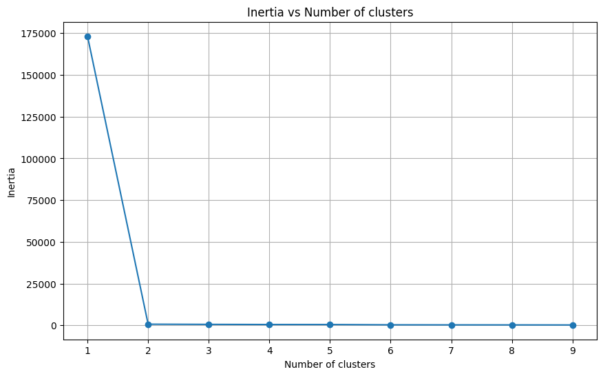

```python
### Exercise ###
# Write code to calculate inertia_ for the model with initial data points, number of clusters from 1 to 10
# Plot the graph to observe the decrease in inertia and choose the appropriate number of clusters
# Generate data corresponding to the hypothesis of 2 clusters

import numpy as np
from sklearn.datasets import make_blobs
from sklearn.cluster import KMeans
import matplotlib.pyplot as plt

n_samples = 1000
random_state = 170
center_points = [[1, 10], [26, 2]]  # randomly generate points around fixed center positions

X, y = make_blobs(n_samples=n_samples, random_state=random_state, centers=center_points, cluster_std=0.6)
print("Data dimensions: ", X.shape, y.shape)
print("First 5 data points: \n", X[:5])

k_cluster = np.arange(1, 10)
inertia = []

for k in k_cluster:
    model = KMeans(n_clusters=k)
    model.fit(X)
    inertia.append(model.inertia_)

plt.figure(figsize=(10, 6))
plt.plot(k_cluster, inertia, marker='o')
plt.xlabel('Number of clusters')
plt.ylabel('Inertia')
plt.title('Inertia vs Number of clusters')
plt.grid(True)
plt.show()
```

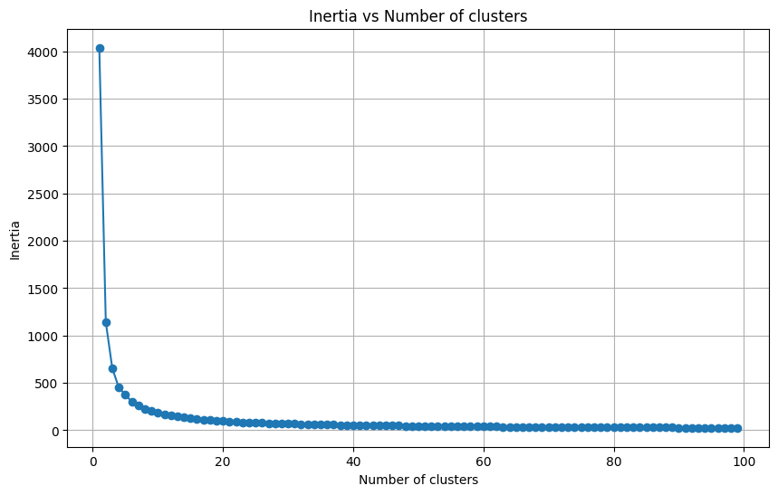

```python
### Exercise ###
# Write code to calculate inertia_ for the model with image data, number of clusters from 1 to 10
# Plot the graph to observe the decrease in inertia and choose the appropriate number of clusters
# code
k_cluster = np.arange(1, 100)
inertia_values = []

for k in k_cluster:
    model = KMeans(n_clusters=k)
    model.fit(data_img)
    inertia_values.append(model.inertia_)

plt.figure(figsize=(10, 6))
plt.plot(k_cluster, inertia_values, marker='o')
plt.xlabel('Number of clusters')
plt.ylabel('Inertia')
plt.title('Inertia vs Number of clusters')
plt.grid(True)
plt.show()
```